# Risk Factor Analysis

## Outcome Variable

**Outcome Variable:** whz

## Predictor Variables

**Intervention Variable:** parity

**Adjustment Set:**

- arm
- W_mage
- meducyrs
- feducyrs
- hhwealth_quart
- W_mhtcm
- W_mwtkg
- W_mbmi
- vagbrth
- W_nrooms
- impsan
- delta_W_mage
- delta_meducyrs
- delta_feducyrs
- delta_hhwealth_quart
- delta_W_mhtcm
- delta_W_mwtkg
- delta_W_mbmi
- delta_vagbrth
- delta_W_nrooms
- delta_impsan

## Stratifying Variables

The analysis was stratified on these variable(s):

- agecat
- studyid
- country

## Data Summary

| agecat | studyid | country | parity | n_cell | n |
| --- | --- | --- | --- | --- | --- |
| Birth | ki1000304b-SAS-CompFeed | INDIA | 1 | 304 | 1103 |
| Birth | ki1000304b-SAS-CompFeed | INDIA | 2 | 258 | 1103 |
| Birth | ki1000304b-SAS-CompFeed | INDIA | 3+ | 541 | 1103 |
| Birth | ki1017093b-PROVIDE | BANGLADESH | 1 | 202 | 532 |
| Birth | ki1017093b-PROVIDE | BANGLADESH | 2 | 182 | 532 |
| Birth | ki1017093b-PROVIDE | BANGLADESH | 3+ | 148 | 532 |
| Birth | ki1101329-Keneba | GAMBIA | 1 | 2 | 10 |
| Birth | ki1101329-Keneba | GAMBIA | 2 | 2 | 10 |
| Birth | ki1101329-Keneba | GAMBIA | 3+ | 6 | 10 |
| Birth | ki1113344-GMS-Nepal | NEPAL | 1 | 185 | 641 |
| Birth | ki1113344-GMS-Nepal | NEPAL | 2 | 169 | 641 |
| Birth | ki1113344-GMS-Nepal | NEPAL | 3+ | 287 | 641 |
| Birth | ki1126311-ZVITAMBO | ZIMBABWE | 1 | 5561 | 12916 |
| Birth | ki1126311-ZVITAMBO | ZIMBABWE | 2 | 3882 | 12916 |
| Birth | ki1126311-ZVITAMBO | ZIMBABWE | 3+ | 3473 | 12916 |
| Birth | ki1135781-COHORTS | GUATEMALA | 1 | 94 | 756 |
| Birth | ki1135781-COHORTS | GUATEMALA | 2 | 118 | 756 |
| Birth | ki1135781-COHORTS | GUATEMALA | 3+ | 544 | 756 |
| Birth | ki1135781-COHORTS | INDIA | 1 | 641 | 3855 |
| Birth | ki1135781-COHORTS | INDIA | 2 | 982 | 3855 |
| Birth | ki1135781-COHORTS | INDIA | 3+ | 2232 | 3855 |
| Birth | ki1135781-COHORTS | PHILIPPINES | 1 | 640 | 2899 |
| Birth | ki1135781-COHORTS | PHILIPPINES | 2 | 657 | 2899 |
| Birth | ki1135781-COHORTS | PHILIPPINES | 3+ | 1602 | 2899 |
| Birth | kiGH5241-JiVitA-3 | BANGLADESH | 1 | 7896 | 22083 |
| Birth | kiGH5241-JiVitA-3 | BANGLADESH | 2 | 7519 | 22083 |
| Birth | kiGH5241-JiVitA-3 | BANGLADESH | 3+ | 6668 | 22083 |
| 6 months | ki1000304b-SAS-CompFeed | INDIA | 1 | 392 | 1334 |
| 6 months | ki1000304b-SAS-CompFeed | INDIA | 2 | 302 | 1334 |
| 6 months | ki1000304b-SAS-CompFeed | INDIA | 3+ | 640 | 1334 |

[output cut: 57 more lines]

The following strata were considered:

- agecat: 24 months, studyid: ki1017093b-PROVIDE, country: BANGLADESH
- agecat: 24 months, studyid: ki1066203-TanzaniaChild2, country: TANZANIA, UNITED REPUBLIC OF
- agecat: 24 months, studyid: ki1101329-Keneba, country: GAMBIA
- agecat: 24 months, studyid: ki1113344-GMS-Nepal, country: NEPAL
- agecat: 24 months, studyid: ki1126311-ZVITAMBO, country: ZIMBABWE
- agecat: 24 months, studyid: ki1135781-COHORTS, country: GUATEMALA
- agecat: 24 months, studyid: ki1135781-COHORTS, country: INDIA
- agecat: 24 months, studyid: ki1135781-COHORTS, country: PHILIPPINES
- agecat: 24 months, studyid: kiGH5241-JiVitA-3, country: BANGLADESH
- agecat: 6 months, studyid: ki1000304b-SAS-CompFeed, country: INDIA
- agecat: 6 months, studyid: ki1000304b-SAS-FoodSuppl, country: INDIA
- agecat: 6 months, studyid: ki1017093b-PROVIDE, country: BANGLADESH
- agecat: 6 months, studyid: ki1066203-TanzaniaChild2, country: TANZANIA, UNITED REPUBLIC OF
- agecat: 6 months, studyid: ki1101329-Keneba, country: GAMBIA
- agecat: 6 months, studyid: ki1113344-GMS-Nepal, country: NEPAL
- agecat: 6 months, studyid: ki1126311-ZVITAMBO, country: ZIMBABWE
- agecat: 6 months, studyid: ki1135781-COHORTS, country: GUATEMALA
- agecat: 6 months, studyid: ki1135781-COHORTS, country: INDIA
- agecat: 6 months, studyid: ki1135781-COHORTS, country: PHILIPPINES
- agecat: 6 months, studyid: kiGH5241-JiVitA-3, country: BANGLADESH
- agecat: Birth, studyid: ki1000304b-SAS-CompFeed, country: INDIA
- agecat: Birth, studyid: ki1017093b-PROVIDE, country: BANGLADESH
- agecat: Birth, studyid: ki1101329-Keneba, country: GAMBIA
- agecat: Birth, studyid: ki1113344-GMS-Nepal, country: NEPAL
- agecat: Birth, studyid: ki1126311-ZVITAMBO, country: ZIMBABWE
- agecat: Birth, studyid: ki1135781-COHORTS, country: GUATEMALA
- agecat: Birth, studyid: ki1135781-COHORTS, country: INDIA
- agecat: Birth, studyid: ki1135781-COHORTS, country: PHILIPPINES
- agecat: Birth, studyid: kiGH5241-JiVitA-3, country: BANGLADESH

### Dropped Strata

Some strata were dropped due to rare outcomes:

- agecat: Birth, studyid: ki1101329-Keneba, country: GAMBIA
- agecat: 24 months, studyid: ki1066203-TanzaniaChild2, country: TANZANIA, UNITED REPUBLIC OF

## Methods Detail

We’re interested in the causal parameters $E[Y_a]$ for all values of $a \in \mathcal{A}$. These parameters represent the mean outcome if, possibly contrary to fact, we intervened to set all units to have $A=a$. Under the randomization and positivity assumptions, these are identified by the statistical parameters $\psi_a=E_W[E_{Y|A,W}(Y|A=a,W)]$. In addition, we’re interested in the mean of $Y$, $E[Y]$ under no intervention (the observed mean). We will estimate these parameters by using SuperLearner to fit the relevant likelihood factors – $E_{Y|A,W}(Y|A=a,W)$ and $p(A=a|W)$, and then updating our likelihood fit using a joint TMLE.

For unadjusted analyses ($W=\{\}$), initial likelihoods were estimated using Lrnr_glm to estimate the simple $E(Y|A)$ and Lrnr_mean to estimate $p(A)$. For adjusted analyses, a small library containing Lrnr_glmnet, Lrnr_xgboost, and Lrnr_mean was used.

Having estimated these parameters, we will then use the delta method to estimate relative risks and attributable risks relative to a prespecified baseline level of $A$.

# Results Detail

## Results Plots

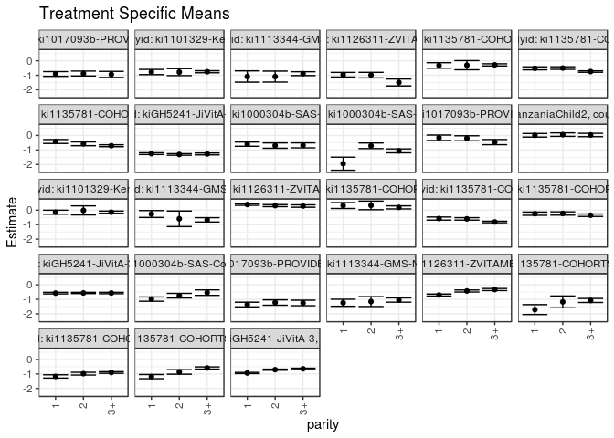

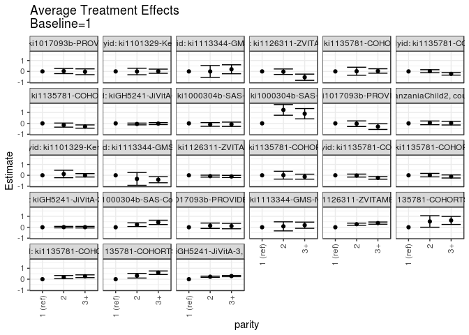

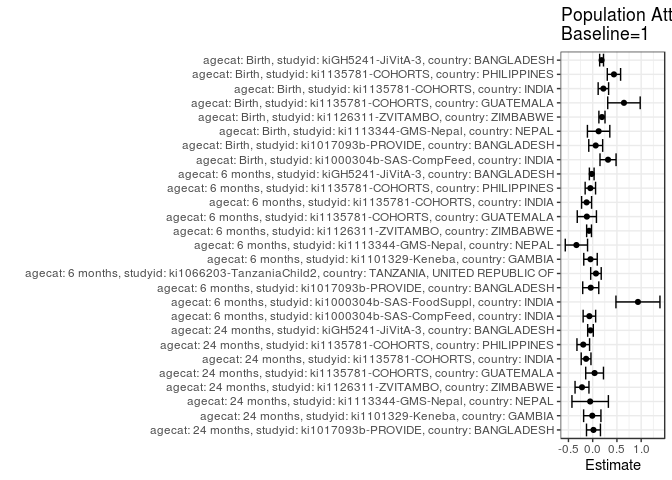

## Results Table

### Parameter: TSM

| agecat | studyid | country | intervention_level | baseline_level | estimate | ci_lower | ci_upper |
| --- | --- | --- | --- | --- | --- | --- | --- |
| Birth | ki1000304b-SAS-CompFeed | INDIA | 1 | NA | -0.9865964 | -1.1353300 | -0.8378628 |
| Birth | ki1000304b-SAS-CompFeed | INDIA | 2 | NA | -0.7492612 | -0.9088426 | -0.5896798 |
| Birth | ki1000304b-SAS-CompFeed | INDIA | 3+ | NA | -0.5388823 | -0.7275149 | -0.3502498 |
| Birth | ki1017093b-PROVIDE | BANGLADESH | 1 | NA | -1.3608557 | -1.5215663 | -1.2001452 |
| Birth | ki1017093b-PROVIDE | BANGLADESH | 2 | NA | -1.2211237 | -1.4067811 | -1.0354664 |
| Birth | ki1017093b-PROVIDE | BANGLADESH | 3+ | NA | -1.2511150 | -1.4406128 | -1.0616172 |
| Birth | ki1113344-GMS-Nepal | NEPAL | 1 | NA | -1.2387463 | -1.4805202 | -0.9969724 |
| Birth | ki1113344-GMS-Nepal | NEPAL | 2 | NA | -1.1559727 | -1.4945723 | -0.8173731 |
| Birth | ki1113344-GMS-Nepal | NEPAL | 3+ | NA | -1.0493666 | -1.1985714 | -0.9001618 |
| Birth | ki1126311-ZVITAMBO | ZIMBABWE | 1 | NA | -0.7065280 | -0.7746529 | -0.6384031 |
| Birth | ki1126311-ZVITAMBO | ZIMBABWE | 2 | NA | -0.4257279 | -0.4971145 | -0.3543413 |
| Birth | ki1126311-ZVITAMBO | ZIMBABWE | 3+ | NA | -0.3258366 | -0.3980246 | -0.2536487 |
| Birth | ki1135781-COHORTS | GUATEMALA | 1 | NA | -1.7071862 | -2.0473726 | -1.3669997 |
| Birth | ki1135781-COHORTS | GUATEMALA | 2 | NA | -1.1763856 | -1.5827825 | -0.7699887 |
| Birth | ki1135781-COHORTS | GUATEMALA | 3+ | NA | -1.0808005 | -1.2191397 | -0.9424613 |
| Birth | ki1135781-COHORTS | INDIA | 1 | NA | -1.1703942 | -1.2836801 | -1.0571083 |
| Birth | ki1135781-COHORTS | INDIA | 2 | NA | -0.9794581 | -1.0736630 | -0.8852532 |
| Birth | ki1135781-COHORTS | INDIA | 3+ | NA | -0.8998470 | -0.9546237 | -0.8450703 |
| Birth | ki1135781-COHORTS | PHILIPPINES | 1 | NA | -1.1812021 | -1.3241208 | -1.0382835 |
| Birth | ki1135781-COHORTS | PHILIPPINES | 2 | NA | -0.8605591 | -1.0168850 | -0.7042332 |
| Birth | ki1135781-COHORTS | PHILIPPINES | 3+ | NA | -0.5877423 | -0.6624594 | -0.5130252 |
| Birth | kiGH5241-JiVitA-3 | BANGLADESH | 1 | NA | -0.9334501 | -0.9744846 | -0.8924157 |
| Birth | kiGH5241-JiVitA-3 | BANGLADESH | 2 | NA | -0.7060326 | -0.7428390 | -0.6692262 |
| Birth | kiGH5241-JiVitA-3 | BANGLADESH | 3+ | NA | -0.6449884 | -0.6871558 | -0.6028210 |
| 6 months | ki1000304b-SAS-CompFeed | INDIA | 1 | NA | -0.5978411 | -0.7453443 | -0.4503379 |
| 6 months | ki1000304b-SAS-CompFeed | INDIA | 2 | NA | -0.6965423 | -0.8804496 | -0.5126350 |
| 6 months | ki1000304b-SAS-CompFeed | INDIA | 3+ | NA | -0.6808644 | -0.8528508 | -0.5088780 |
| 6 months | ki1000304b-SAS-FoodSuppl | INDIA | 1 | NA | -1.9457143 | -2.3960187 | -1.4954099 |
| 6 months | ki1000304b-SAS-FoodSuppl | INDIA | 2 | NA | -0.7120833 | -0.9054564 | -0.5187103 |
| 6 months | ki1000304b-SAS-FoodSuppl | INDIA | 3+ | NA | -1.0622259 | -1.1982227 | -0.9262292 |

[output cut: 51 more lines]

### Parameter: E(Y)

| agecat | studyid | country | intervention_level | baseline_level | estimate | ci_lower | ci_upper |
| --- | --- | --- | --- | --- | --- | --- | --- |
| Birth | ki1000304b-SAS-CompFeed | INDIA | NA | NA | -0.6700453 | -0.8474950 | -0.4925957 |
| Birth | ki1017093b-PROVIDE | BANGLADESH | NA | NA | -1.2984586 | -1.3752758 | -1.2216415 |
| Birth | ki1113344-GMS-Nepal | NEPAL | NA | NA | -1.1164431 | -1.2040134 | -1.0288728 |
| Birth | ki1126311-ZVITAMBO | ZIMBABWE | NA | NA | -0.5156349 | -0.5414936 | -0.4897762 |
| Birth | ki1135781-COHORTS | GUATEMALA | NA | NA | -1.0621429 | -1.1631387 | -0.9611471 |
| Birth | ki1135781-COHORTS | INDIA | NA | NA | -0.9498080 | -0.9874148 | -0.9122013 |
| Birth | ki1135781-COHORTS | PHILIPPINES | NA | NA | -0.7427251 | -0.7890855 | -0.6963647 |
| Birth | kiGH5241-JiVitA-3 | BANGLADESH | NA | NA | -0.7501567 | -0.7680049 | -0.7323085 |
| 6 months | ki1000304b-SAS-CompFeed | INDIA | NA | NA | -0.6657084 | -0.8024377 | -0.5289791 |
| 6 months | ki1000304b-SAS-FoodSuppl | INDIA | NA | NA | -1.0121579 | -1.1280429 | -0.8962729 |
| 6 months | ki1017093b-PROVIDE | BANGLADESH | NA | NA | -0.1990907 | -0.2817968 | -0.1163845 |
| 6 months | ki1066203-TanzaniaChild2 | TANZANIA, UNITED REPUBLIC OF | NA | NA | 0.0797179 | 0.0266621 | 0.1327737 |
| 6 months | ki1101329-Keneba | GAMBIA | NA | NA | -0.1873900 | -0.2456638 | -0.1291162 |
| 6 months | ki1113344-GMS-Nepal | NEPAL | NA | NA | -0.6038416 | -0.6899448 | -0.5177384 |
| 6 months | ki1126311-ZVITAMBO | ZIMBABWE | NA | NA | 0.3106432 | 0.2849661 | 0.3363203 |
| 6 months | ki1135781-COHORTS | GUATEMALA | NA | NA | 0.1940810 | 0.1226351 | 0.2655269 |
| 6 months | ki1135781-COHORTS | INDIA | NA | NA | -0.7068611 | -0.7417800 | -0.6719423 |
| 6 months | ki1135781-COHORTS | PHILIPPINES | NA | NA | -0.2938433 | -0.3352064 | -0.2524802 |
| 6 months | kiGH5241-JiVitA-3 | BANGLADESH | NA | NA | -0.5930207 | -0.6125866 | -0.5734549 |
| 24 months | ki1017093b-PROVIDE | BANGLADESH | NA | NA | -0.8928670 | -0.9755153 | -0.8102187 |
| 24 months | ki1101329-Keneba | GAMBIA | NA | NA | -0.7834078 | -0.8357743 | -0.7310414 |
| 24 months | ki1113344-GMS-Nepal | NEPAL | NA | NA | -1.1363107 | -1.2252817 | -1.0473398 |
| 24 months | ki1126311-ZVITAMBO | ZIMBABWE | NA | NA | -1.1817824 | -1.2809226 | -1.0826422 |
| 24 months | ki1135781-COHORTS | GUATEMALA | NA | NA | -0.2813755 | -0.3354674 | -0.2272835 |
| 24 months | ki1135781-COHORTS | INDIA | NA | NA | -0.6564729 | -0.6914450 | -0.6215007 |
| 24 months | ki1135781-COHORTS | PHILIPPINES | NA | NA | -0.6099592 | -0.6467541 | -0.5731643 |
| 24 months | kiGH5241-JiVitA-3 | BANGLADESH | NA | NA | -1.2994214 | -1.3227674 | -1.2760754 |

### Parameter: ATE

| agecat | studyid | country | intervention_level | baseline_level | estimate | ci_lower | ci_upper |
| --- | --- | --- | --- | --- | --- | --- | --- |
| Birth | ki1000304b-SAS-CompFeed | INDIA | 1 | 1 | 0.0000000 | 0.0000000 | 0.0000000 |
| Birth | ki1000304b-SAS-CompFeed | INDIA | 2 | 1 | 0.2373352 | 0.0674894 | 0.4071811 |
| Birth | ki1000304b-SAS-CompFeed | INDIA | 3+ | 1 | 0.4477141 | 0.2512572 | 0.6441709 |
| Birth | ki1017093b-PROVIDE | BANGLADESH | 1 | 1 | 0.0000000 | 0.0000000 | 0.0000000 |
| Birth | ki1017093b-PROVIDE | BANGLADESH | 2 | 1 | 0.1397320 | -0.1056542 | 0.3851182 |
| Birth | ki1017093b-PROVIDE | BANGLADESH | 3+ | 1 | 0.1097407 | -0.1387306 | 0.3582121 |
| Birth | ki1113344-GMS-Nepal | NEPAL | 1 | 1 | 0.0000000 | 0.0000000 | 0.0000000 |
| Birth | ki1113344-GMS-Nepal | NEPAL | 2 | 1 | 0.0827736 | -0.3334261 | 0.4989733 |
| Birth | ki1113344-GMS-Nepal | NEPAL | 3+ | 1 | 0.1893797 | -0.0949315 | 0.4736910 |
| Birth | ki1126311-ZVITAMBO | ZIMBABWE | 1 | 1 | 0.0000000 | 0.0000000 | 0.0000000 |
| Birth | ki1126311-ZVITAMBO | ZIMBABWE | 2 | 1 | 0.2808001 | 0.1821822 | 0.3794180 |
| Birth | ki1126311-ZVITAMBO | ZIMBABWE | 3+ | 1 | 0.3806914 | 0.2814878 | 0.4798951 |
| Birth | ki1135781-COHORTS | GUATEMALA | 1 | 1 | 0.0000000 | 0.0000000 | 0.0000000 |
| Birth | ki1135781-COHORTS | GUATEMALA | 2 | 1 | 0.5308006 | 0.0016069 | 1.0599942 |
| Birth | ki1135781-COHORTS | GUATEMALA | 3+ | 1 | 0.6263857 | 0.2589960 | 0.9937754 |
| Birth | ki1135781-COHORTS | INDIA | 1 | 1 | 0.0000000 | 0.0000000 | 0.0000000 |
| Birth | ki1135781-COHORTS | INDIA | 2 | 1 | 0.1909361 | 0.0435577 | 0.3383145 |
| Birth | ki1135781-COHORTS | INDIA | 3+ | 1 | 0.2705473 | 0.1446902 | 0.3964043 |
| Birth | ki1135781-COHORTS | PHILIPPINES | 1 | 1 | 0.0000000 | 0.0000000 | 0.0000000 |
| Birth | ki1135781-COHORTS | PHILIPPINES | 2 | 1 | 0.3206430 | 0.1086679 | 0.5326181 |
| Birth | ki1135781-COHORTS | PHILIPPINES | 3+ | 1 | 0.5934598 | 0.4319314 | 0.7549882 |
| Birth | kiGH5241-JiVitA-3 | BANGLADESH | 1 | 1 | 0.0000000 | 0.0000000 | 0.0000000 |
| Birth | kiGH5241-JiVitA-3 | BANGLADESH | 2 | 1 | 0.2274175 | 0.1734089 | 0.2814262 |
| Birth | kiGH5241-JiVitA-3 | BANGLADESH | 3+ | 1 | 0.2884618 | 0.2302054 | 0.3467181 |
| 6 months | ki1000304b-SAS-CompFeed | INDIA | 1 | 1 | 0.0000000 | 0.0000000 | 0.0000000 |
| 6 months | ki1000304b-SAS-CompFeed | INDIA | 2 | 1 | -0.0987012 | -0.2700008 | 0.0725983 |
| 6 months | ki1000304b-SAS-CompFeed | INDIA | 3+ | 1 | -0.0830233 | -0.2794597 | 0.1134130 |
| 6 months | ki1000304b-SAS-FoodSuppl | INDIA | 1 | 1 | 0.0000000 | 0.0000000 | 0.0000000 |
| 6 months | ki1000304b-SAS-FoodSuppl | INDIA | 2 | 1 | 1.2336310 | 0.7435624 | 1.7236995 |
| 6 months | ki1000304b-SAS-FoodSuppl | INDIA | 3+ | 1 | 0.8834884 | 0.4130958 | 1.3538809 |

[output cut: 51 more lines]

### Parameter: PAR

| agecat | studyid | country | intervention_level | baseline_level | estimate | ci_lower | ci_upper |
| --- | --- | --- | --- | --- | --- | --- | --- |
| Birth | ki1000304b-SAS-CompFeed | INDIA | 1 | NA | 0.3165511 | 0.1508399 | 0.4822623 |
| Birth | ki1017093b-PROVIDE | BANGLADESH | 1 | NA | 0.0623971 | -0.0809623 | 0.2057565 |
| Birth | ki1113344-GMS-Nepal | NEPAL | 1 | NA | 0.1223033 | -0.1085644 | 0.3531710 |
| Birth | ki1126311-ZVITAMBO | ZIMBABWE | 1 | NA | 0.1908932 | 0.1278497 | 0.2539367 |
| Birth | ki1135781-COHORTS | GUATEMALA | 1 | NA | 0.6450433 | 0.3102050 | 0.9798817 |
| Birth | ki1135781-COHORTS | INDIA | 1 | NA | 0.2205862 | 0.1128639 | 0.3283085 |
| Birth | ki1135781-COHORTS | PHILIPPINES | 1 | NA | 0.4384770 | 0.3011713 | 0.5757827 |
| Birth | kiGH5241-JiVitA-3 | BANGLADESH | 1 | NA | 0.1832934 | 0.1439290 | 0.2226579 |
| 6 months | ki1000304b-SAS-CompFeed | INDIA | 1 | NA | -0.0678673 | -0.1969835 | 0.0612489 |
| 6 months | ki1000304b-SAS-FoodSuppl | INDIA | 1 | NA | 0.9335564 | 0.4796129 | 1.3874999 |
| 6 months | ki1017093b-PROVIDE | BANGLADESH | 1 | NA | -0.0401075 | -0.2056131 | 0.1253981 |
| 6 months | ki1066203-TanzaniaChild2 | TANZANIA, UNITED REPUBLIC OF | 1 | NA | 0.0673467 | -0.0412471 | 0.1759404 |
| 6 months | ki1101329-Keneba | GAMBIA | 1 | NA | -0.0450714 | -0.1841914 | 0.0940486 |
| 6 months | ki1113344-GMS-Nepal | NEPAL | 1 | NA | -0.3355976 | -0.5654760 | -0.1057193 |
| 6 months | ki1126311-ZVITAMBO | ZIMBABWE | 1 | NA | -0.0746132 | -0.1245948 | -0.0246315 |
| 6 months | ki1135781-COHORTS | GUATEMALA | 1 | NA | -0.1204900 | -0.3183262 | 0.0773462 |
| 6 months | ki1135781-COHORTS | INDIA | 1 | NA | -0.1258179 | -0.2290396 | -0.0225963 |
| 6 months | ki1135781-COHORTS | PHILIPPINES | 1 | NA | -0.0480434 | -0.1554037 | 0.0593169 |
| 6 months | kiGH5241-JiVitA-3 | BANGLADESH | 1 | NA | -0.0196738 | -0.0682862 | 0.0289385 |
| 24 months | ki1017093b-PROVIDE | BANGLADESH | 1 | NA | 0.0162678 | -0.1276763 | 0.1602119 |
| 24 months | ki1101329-Keneba | GAMBIA | 1 | NA | -0.0083536 | -0.1868234 | 0.1701162 |
| 24 months | ki1113344-GMS-Nepal | NEPAL | 1 | NA | -0.0520370 | -0.4278015 | 0.3237275 |
| 24 months | ki1126311-ZVITAMBO | ZIMBABWE | 1 | NA | -0.2203972 | -0.3638398 | -0.0769545 |
| 24 months | ki1135781-COHORTS | GUATEMALA | 1 | NA | 0.0393999 | -0.1439190 | 0.2227187 |
| 24 months | ki1135781-COHORTS | INDIA | 1 | NA | -0.1361758 | -0.2367501 | -0.0356016 |
| 24 months | ki1135781-COHORTS | PHILIPPINES | 1 | NA | -0.1944709 | -0.3245698 | -0.0643720 |
| 24 months | kiGH5241-JiVitA-3 | BANGLADESH | 1 | NA | -0.0452555 | -0.1032204 | 0.0127094 |